# Clear Outcomes Trial

# Bayesian Model with Conjugate Multivariate Normal Priors

## CLEAR TRIAL

- Aim was to find a clinically meaninful difference on MACE using Bempedoic Acid in statin-intolerance patients.
- Let’s first compare the primary outcomes (found significant) using a unimodal Normal shrinkage prior. We take advantage that the logOR is approximately normally distributed, and that the normal distribution has a conjugate (normal) prior. This means that the Posterior and Prior take the same form, and in the case of the normal distribtuion, so does the likelihood!

### Univariate primary outcomes

1. Skeptical Prior

**Definition:** A skeptical prior is centered at 0, with the standard deviation calculated such that only 10% of the probability mass is to the left of the Minimal Clinically Important Difference (MCID).

To choose the MCID, we use a NNT of 25 over ten years (as adopted by [major guidelines](https://jamanetwork.com/journals/jamacardiology/fullarticle/2752379) and find that this translates to a 1.3% ARR per 40 months.

Let MCID be the minimal clinically important difference converted to its log odds ratio equivalent, log_mcid. To find the standard deviation (sigma_skeptical), determine the z-score that leaves 90% of the distribution to the right of log_mcid. This z-score corresponds to the 10th percentile of the standard normal distribution.

```r
# Given data from the table
n_treatment <- 6992
events_treatment <- 819
n_control <- 6978
events_control <- 927

# Calculate the odds ratio (OR)
or <- (events_treatment / (n_treatment - events_treatment)) / (events_control / (n_control - events_control))

# Convert OR to logOR
log_or <- log(or)

# Calculate the standard error of the logOR
se_log_or <- sqrt((1 / events_treatment) + (1 / (n_treatment - events_treatment)) + (1 / events_control) + (1 / (n_control - events_control)))
```

Now we need to define the MCID as an absolute risk reduction of 1.3% and convert the absolute risk reduction to logOR for MCID. We show that the baseline risk in our population is events in control/n_control:

```r
mcid_arr <- 0.013

# Assuming a baseline risk from the control group
(baseline_risk <- events_control / n_control)
```

```
## [1] 0.1328461
```

```r
# Calculate the risk in the treatment group
risk_treatment <- baseline_risk - mcid_arr

# Calculate the odds for control and treatment
odds_control <- baseline_risk / (1 - baseline_risk)
odds_treatment <- risk_treatment / (1 - risk_treatment)

# Calculate the odds ratio (OR)
or_mcid <- odds_treatment / odds_control

# For Bayesian analysis, we often use the natural log of the OR
log_mcid <- log(or_mcid)
```

The risk in the treated group is the baseline risk minus the mcid_arr, and the ARR of 1.3% translates to an log OR of MCID of -0.1178632

Here we show that these infact produce desired priors:

```r
# here there is a 10% probability of the log_mcid
z_skeptical <- qnorm(0.10)
sigma_skeptical <- abs(log_mcid / z_skeptical)
pnorm(log_mcid,sd=sigma_skeptical)
```

```
## [1] 0.1
```

**Enthusiastic Prior Definition:** An enthusiastic prior is centered at MCID, with the standard deviation calculated such that there is a 30% probability of harm (logOR > 0).

For the enthusiastic prior, we want 70% of the distribution to be below 0 when the mean is at log_mcid. To find the standard deviation (sigma_enthusiastic), calculate the z-score that corresponds to the 70th percentile of the standard normal distribution.

We show that our choice of sigma in fact translates to this:

```r
z_enthusiastic <- qnorm(0.70)
sigma_enthusiastic <- abs((0 - log_mcid) / z_enthusiastic)
pnorm(0,mean=log_mcid,sd = sigma_enthusiastic)
```

```
## [1] 0.7
```

**Pessimistic Prior Definition:** A pessimistic prior is centered at -MCID, with the standard deviation calculated such that there is a 30% probability of benefit (logOR < 0).

For the pessimistic prior, we want 70% of the distribution to be above 0 when the mean is at -log_mcid. To find the standard deviation (sigma_pessimistic), calculate the z-score that corresponds to the 30th percentile of the standard normal distribution.

```r
z_pessimistic <- qnorm(0.30)
sigma_pessimistic <- abs((0 + log_mcid) / z_pessimistic)

pnorm(0,mean=-log_mcid,sd = sigma_pessimistic)
```

```
## [1] 0.3
```

```r
# Install necessary packages if not already installed
if (!require("metafor")) install.packages("metafor")
library(rstan)
library(metafor)
library(reshape)
library(ggplot2)
library(MASS)
library(ggplot2)
library(reshape2)  # For melting data frames
library(gridExtra)  #
library(ggpubr)

# Load necessary library
library(tidyverse)

# Given data from the table
n_treatment <- 6992
events_treatment <- 819
n_control <- 6978
events_control <- 927

# Calculate the odds ratio (OR)
or <- (events_treatment / (n_treatment - events_treatment)) / (events_control / (n_control - events_control))

# Convert OR to logOR
log_or <- log(or)

# Calculate the standard error of the logOR
se_log_or <- sqrt((1 / events_treatment) + (1 / (n_treatment - events_treatment)) + (1 / events_control) + (1 / (n_control - events_control)))

# Define the MCID as an absolute risk reduction of 1.3%
mcid_arr <- 0.013
# Convert the absolute risk reduction to logOR for MCID
# Assuming a baseline risk from the control group
baseline_risk <- events_control / n_control

# Calculate the risk in the treatment group
risk_treatment <- baseline_risk - mcid_arr

# Calculate the odds for control and treatment
odds_control <- baseline_risk / (1 - baseline_risk)
odds_treatment <- risk_treatment / (1 - risk_treatment)

# Calculate the odds ratio (OR)
or <- odds_treatment / odds_control

# For Bayesian analysis, we often use the natural log of the OR
log_or <- log(or)

# Define the priors based on the specifications

# Skeptical Prior: 90% certainty of no clinically relevant effect, so only 10% of area
skeptical_sd <- abs(log_mcid / qnorm(0.10))
skeptical_prior <- list(mu = 0, sigma = skeptical_sd)

# Enthusiastic Prior: 30% probability of harm
enthusiastic_sd <- abs(log_mcid) / qnorm(0.70)
enthusiastic_prior <- list(mu = log_mcid, sigma = enthusiastic_sd)

# Pessimistic Prior: 30% probability of benefit
pessimistic_sd <- abs(log_mcid) / qnorm(0.70)
pessimistic_prior <- list(mu = -log_mcid, sigma = pessimistic_sd)

# Output the calculated values and the priors
list(
  log_or = log_or,
  se_log_or = se_log_or,
  skeptical_prior = skeptical_prior,
  enthusiastic_prior = enthusiastic_prior,
  pessimistic_prior = pessimistic_prior
)
```

```
## $log_or
## [1] -0.1178632
##
## $se_log_or
## [1] 0.05125434
##
## $skeptical_prior
## $skeptical_prior$mu
## [1] 0
##
## $skeptical_prior$sigma
## [1] 0.09196915
##
##
## $enthusiastic_prior
## $enthusiastic_prior$mu
## [1] -0.1178632
##
## $enthusiastic_prior$sigma
## [1] 0.224758
##
##
## $pessimistic_prior
## $pessimistic_prior$mu
## [1] 0.1178632
##
## $pessimistic_prior$sigma
## [1] 0.224758
```

## Conjugate analysis:

- We show the skeptical, ethnusiastic, and pessimistic result using the respective priors
- Recall that the posterior mean and variance are calculated using the following formulas:

**Posterior Mean:**
$$\mu_{\text{post}} = \frac{\mu_{\text{prior}} / \sigma_{\text{prior}}^2 +
\mu_{\text{likelihood}} / \sigma_{\text{likelihood}}^2}{1 /
\sigma_{\text{prior}}^2 + 1 / \sigma_{\text{likelihood}}^2}$$

**Posterior Variance:**
$$\sigma_{\text{post}}^2 = \frac{1}{1 / \sigma_{\text{prior}}^2 + 1 /
\sigma_{\text{likelihood}}^2}$$

Where:

- $\mu_{\text{prior}}$ and $\sigma_{\text{prior}}$ are the mean and standard deviation of the prior distribution.
- $\mu_{\text{likelihood}}$ and $\sigma_{\text{likelihood}}$ are the mean and standard deviation of the likelihood.

So you can see that the posterior mean is really a weighted average of the data and prior mean, with more emphasis placed on the one with a smaller variance.

```r
# Function to calculate the posterior
calc_conjugate_posterior <- function(log_or, se, prior) {
  var_prior <- prior$sigma^2
  var_data <- se^2
  var_post <- 1 / (1 / var_prior + 1 / var_data)
  mu_post <- var_post * (log_or / var_data + prior$mu / var_prior)
  return(list(mu = mu_post, sigma = sqrt(var_post)))
}

# Calculate the posterior for the skeptical prior
posterior_skeptical <- calc_conjugate_posterior(log_or, se_log_or, skeptical_prior)


posterior_enthus <- calc_conjugate_posterior(log_or, se_log_or, enthusiastic_prior)

posterior_pess <- calc_conjugate_posterior(log_or, se_log_or, pessimistic_prior)
```

- posterior skeptical:-0.0899319, 0.0447712
- posterior enthusiastic:-0.1178632, 0.0499715
- posterior pessimistic: -0.1062106, 0.0499715

### Summaries

We can return the probabilities for the log OR of 0 and for the MCID here:

- Under a noninformative prior:

```r
pnorm(0,mean = log_or,sd = se_log_or)
```

```
## [1] 0.9892639
```

```r
pnorm(log_mcid,mean = log_or,sd = se_log_or)
```

```
## [1] 0.5
```

- Under a skeptical prior

```r
pnorm(0,mean = posterior_skeptical$mu,sd = posterior_skeptical$sigma)
```

```
## [1] 0.9777156
```

```r
pnorm(log_mcid,mean = posterior_skeptical$mu,sd = posterior_skeptical$sigma)
```

```
## [1] 0.2663573
```

- the enthusiastic prior

```r
pnorm(0,mean = posterior_enthus$mu,sd = posterior_enthus$sigma)
```

```
## [1] 0.9908282
```

```r
pnorm(log_mcid,mean = posterior_enthus$mu,sd = posterior_enthus$sigma)
```

```
## [1] 0.5
```

- the pessimistic prior

```r
pnorm(0,mean = posterior_pess$mu,sd = posterior_pess$sigma)
```

```
## [1] 0.9832244
```

```r
pnorm(log_mcid,mean = posterior_pess$mu,sd = posterior_pess$sigma)
```

```
## [1] 0.407809
```

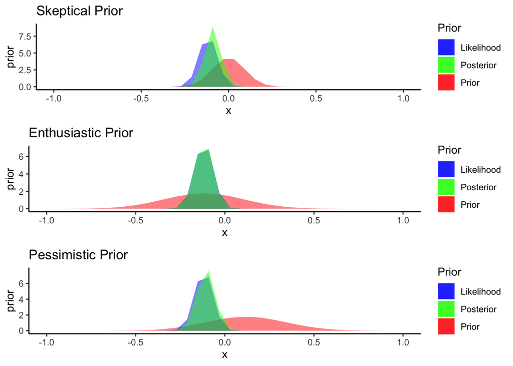

```r
# Your existing data and calculations here...

# Function to generate a density plot for prior, likelihood, and posterior
# Function to generate a plot with shaded areas for prior, likelihood, and posterior
plot_distribution_shaded <- function(title, prior, likelihood, posterior) {
  # Creating a data frame for plotting
  x_values <- seq(-3, 3, length.out = 100)
  df <- data.frame(
    x = x_values,
    prior = dnorm(x_values, mean = prior$mu, sd = prior$sigma),
    likelihood = dnorm(x_values, mean = likelihood$mu, sd = likelihood$sigma),
    posterior = dnorm(x_values, mean = posterior$mu, sd = posterior$sigma)
  )

  # Plotting with shaded areas
  ggplot(df) +
    geom_area(aes(x = x, y = prior, fill = "Prior"), alpha = 0.5, color = NA) +
    geom_area(aes(x = x, y = likelihood, fill = "Likelihood"), alpha = 0.5, color = NA) +
    geom_area(aes(x = x, y = posterior, fill = "Posterior"), alpha = 0.5, color = NA) +
    scale_fill_manual(values = c("Prior" = "red", "Likelihood" = "blue", "Posterior" = "green")) +
    lims(x=c(-1,1))+
    ggtitle(title) +
    labs(fill="Prior")+
    theme_classic()
    # Remove legend if not needed
}

# Define the likelihood (assumed normal distribution around log_or with standard error se_log_or)
likelihood <- list(mu = log_or, sigma = se_log_or)

# Plotting for each prior
p1 <- plot_distribution_shaded("Skeptical Prior", skeptical_prior, likelihood, posterior_skeptical)
p2 <- plot_distribution_shaded("Enthusiastic Prior", enthusiastic_prior, likelihood, posterior_enthus)
p3 <- plot_distribution_shaded("Pessimistic Prior", pessimistic_prior, likelihood, posterior_pess)

# Combining the plots in 3 rows
combined_plot <- ggarrange(p1, p2, p3, ncol = 1, nrow = 3)

# Display the combined plot
print(combined_plot)
```

**We Show that this approximates the MCMC result**

```r
tryCatch({
  # Your R code that might cause errors
}, error = function(e) {
  # Write the error to a log file
  writeLines(as.character(e$message), "error_log.txt")
})

library(rstanarm)
# Globally set stan.verbose to FALSE
options(stan.verbose = FALSE)
# Redirect all output to NULL during model fitting
sink(file = "/dev/null", type = "output")

stan_model_code <- "
data {
  real logOR;             // Log odds ratio
  real<lower=0> SE;       // Standard error
  real<lower=0> sd_prior; // Standard deviation of the  prior
  real mu_prior; // mean of the  prior
}
parameters {
  real theta;  // Parameter (log odds ratio) to estimate
}
model {
  // Skeptical prior for theta
  theta ~ normal(mu_prior, sd_prior);

  // Likelihood
  logOR ~ normal(theta, SE);
}
"

stan_data <- list(logOR = log_or, SE = se_log_or, sd_prior = 20,mu_prior=0)

# Run MCMC simulation
fit <- stan(model_code = stan_model_code, data = stan_data, iter = 4000, chains = 4,verbose = FALSE,refresh=0)
```

- Extract the results of the noninformative prior

```r
summary(fit)$summary
```

```
##             mean     se_mean         sd       2.5%        25%        50%
## theta -0.1190184 0.000965814 0.05119108 -0.2181327 -0.1539931 -0.1197281
## lp__  -0.4989791 0.011665851 0.68623136 -2.5002741 -0.6702818 -0.2342270
##               75%         97.5%    n_eff     Rhat
## theta -0.08417551 -0.0193242113 2809.322 1.002302
## lp__  -0.05162869 -0.0005870893 3460.256 1.001259
```

- Extract the results of the skeptical prior

```r
# Prepare data for Stan, including skeptical_sd
stan_data <- list(logOR = log_or, SE = se_log_or, sd_prior = skeptical_sd,mu_prior=0)

# Run MCMC simulation
fit <- stan(model_code = stan_model_code, data = stan_data, iter = 4000, chains = 4,verbose = FALSE,refresh=0)

summary(fit)$summary
```

```
##              mean      se_mean         sd       2.5%       25%         50%
## theta -0.09028089 0.0008252377 0.04535431 -0.1801585 -0.120776 -0.08982173
## lp__  -1.13965778 0.0121423361 0.71429912 -3.2075300 -1.302335 -0.85975905
##               75%        97.5%    n_eff     Rhat
## theta -0.05960358 -0.001733036 3020.502 1.001175
## lp__  -0.67864085 -0.627069315 3460.634 1.001848
```

**For the enthusiastic**

- Prepare data for Stan, including enthusiastic_sd

```r
stan_data <- list(logOR = log_or, SE = se_log_or, mu_prior=enthusiastic_prior$mu,sd_prior = enthusiastic_prior$sigma)

# Run MCMC simulation
fit <- stan(model_code = stan_model_code, data = stan_data, iter = 4000, chains = 4,verbose = FALSE,refresh=0)

# Extract the results
summary(fit)$summary
```

```
##             mean      se_mean         sd       2.5%        25%        50%
## theta -0.1179424 0.0009433075 0.04968532 -0.2156184 -0.1519594 -0.1177900
## lp__  -0.4942296 0.0116197855 0.68910017 -2.4374946 -0.6670073 -0.2329416
##               75%         97.5%    n_eff     Rhat
## theta -0.08374225 -0.0222816187 2774.275 1.000974
## lp__  -0.05055180 -0.0004902885 3516.969 1.000826
```

**now for pessimistic**

- Prepare data for Stan, including skeptical_sd

```r
stan_data <- list(logOR = log_or, SE = se_log_or, mu_prior=pessimistic_prior$mu,sd_prior = pessimistic_prior$sigma)

# Run MCMC simulation
fit <- stan(model_code = stan_model_code, data = stan_data, iter = 4000, chains = 4,verbose = FALSE,refresh=0)

# Extract the results
summary(fit)$summary
```

```
##             mean      se_mean         sd       2.5%        25%        50%
## theta -0.1050432 0.0008931921 0.04967862 -0.2034079 -0.1394027 -0.1051814
## lp__  -1.0171722 0.0112150759 0.69290431 -2.9764137 -1.1779906 -0.7580731
##               75%        97.5%    n_eff     Rhat
## theta -0.07098649 -0.008793019 3093.494 1.001058
## lp__  -0.57177907 -0.523199084 3817.175 1.000266
```

We can see that these results demonstrate the conjugate normal is perfectly approximated by MCMC here.

## Reference Prior

Now for the reference prior, we will perform a Bayesian meta analysis, and then use the results in both a conjugate and MCMC analysis to show the results match.

A separate baseline risk of CAD for each study (via factor(study)). A common treatment effect of Bempedoic acid across all studies (via the bpd term).

Variation in the treatment effect of Bpd across different studies (via the random effect (bpd - 1|study)).

# Bayesian Hierarchical Model for MACE Data

## Model Structure

The model is structured to estimate the effect of a treatment (BPD) on the occurrence of MACE (Major Adverse Cardiac Events) across different studies.

### Stage I: Data Model (Likelihood)

At this level, the model specifies the observed counts of MACE within each study:

- $Y_{ij} | p_{ij} \sim \text{Binomial}(n_{ij}, p_{ij})$

Where:

- $Y_{ij}$ represents the number of MACE observed in the $i$-th treatment group of the $j$-th study.
- $n_{ij}$ is the total number of trials or participants in the $i$-th treatment group of the $j$-th study.
- $p_{ij}$ is the probability of MACE in the $i$-th treatment group of the $j$-th study.

### Stage II: Parameter Model (Fixed and Random Effects)

The model for the log-odds of MACE combines study-specific baselines and treatment effects:

- $\text{logit}(p_{ij}) = \alpha_j \cdot \text{Study}_{j} + \beta \cdot \text{BPD}_{i} + u_{j} \cdot \text{BPD}_{ij}$

Where:

- $\alpha_j$ is the study-specific intercept (baseline log-odds of MACE when BPD=0).
- $\text{Study}_{j}$ is the study-specific indicator for the $j$-th study (0 for $k \neq j$)
- $\beta$ is the fixed effect of the BPD treatment (the average log-odds ratio of MACE for BPD=1 versus BPD=0) across all studies (no j)
- $u_{j}$ is the random effect representing the study-specific deviation in treatment effect from the average treatment effect $\beta$.
- $\text{BPD}_{ij}$ is the treatment indicator (0 for absence, 1 for presence) for the $i$-th group in the $j$-th study.

### Stage III: Hyperparameter Model (Priors)

The model defines priors for parameters and hyperparameters as follows:

- Priors for $\alpha_j$: $\alpha_j \sim \text{Normal}(\mu_{\alpha}, \sigma_{\alpha}^2)$
- Prior for $\beta$: $\beta \sim \text{Normal}(\mu_{\beta}, \sigma_{\beta}^2)$
- Priors for $u_{j}$: $u_{j} \sim \text{Normal}(0, \sigma_{u}^2)$

### Stage IV: Prior Specification

Priors are specified based on domain knowledge or assumptions:

- $\mu_{\alpha}$, the mean of the normal prior for the baseline rate, might be set to $-3.2$ based on the 4% baseline MACE rate.
- $\sigma_{\alpha}$, the standard deviation of the baseline rate across studies, would be set according to expected variability.
- $\mu_{\beta}$ and $\sigma_{\beta}$, the mean and standard deviation for the treatment effect, would be based on prior belief about the effectiveness of BPD.
- $\sigma_{u}$, the standard deviation of the random slopes, represents between-study variability in the treatment effect.

```r
#Trial 1: goldberg et al
goldberg <- data.frame(
  study = "goldberg",
  #Trial name
  total_n = c(522, 257),
  #Total sample size in each group
  events_n = c(32, 21),
  #Patients with MACE in each group
  bpd = c(1,0) #bpd (Yes/No)
)

#Trial 2: laufs et al
laufs <- data.frame(
  study = "laufs",
  #Trial name
  total_n = c(234, 111),
  #Total sample size in each group
  events_n = c(9, 0),
  #Patients with MACE in each group
  bpd = c(1,0) #bpd 1/0 (Yes/No)
)


#Trial 3: Ray
ray <- data.frame(
  study = "ray",
  #Trial name
  total_n = c(1487, 742),
  #Total sample size in each group
  events_n = c(68, 42),
  #Patients with MACE in each group
  bpd = c(1,0) #bpd 1/0 (Yes/No)
)


#Combine the data from the 6 trials into a single dataframe
combined_data <- rbind(goldberg, ray, laufs)
```

First, we will conduct a meta-analysis of the 3 RCTs that tested bempedoic acid. This meta-analysis will form the basis of our subsequent prior.

Now, we will set up our priors (on the log-odds scale), as we recall that the natural link for a binomial process is the logit function, and the logOR is normally distributed.

Treatment effect prior, is `flat’ suggesting that all the information will be gelamed from the observed studies which will inform our later posterior

Fixed effect prior for MACE within the population, which is centered on the logOR of 6% (-2.8) that we observe in the placebo arms here

Heterogeneity prior, a ‘fat tailed’ cauchy prior with sd 0.5, commonly chosen in meta analyses

We write this as a formula
$$events/total
\propto 0 + factor(study) + bpd + (bpd - 1 | study)$$

1. The baseline MACE rate for each study, which is captured by `0 + factor(study)`. This part of the model says that each study has its own baseline rate of MACE, with no overall intercept (because of the `0 +`).
2. The shared treatment effect of BPD, which is captured by `bpd`. This is a fixed effect that is consistent across all studies. It represents the average effect of BPD on MACE across all studies.
3. The random effect of BPD by study, which is captured by `(bpd - 1 | study)`. This term allows the effect of BPD to vary for each study around the overall average treatment effect. This is where the variability in treatment effect between studies is modeled.

Given out description, here’s how we should set your priors:

So, your priors could look something like this:

```r
# Set priors for the baseline MACE rate for each study
study_priors <- c(
  prior(normal(-2.8, 0.5), class = "b", coef = "factorstudygoldberg"),
  prior(normal(-2.8, 0.5), class = "b", coef = "factorstudylaufs"),
  prior(normal(-2.8, 0.5), class = "b", coef = "factorstudyray")
)

# Set a prior for the shared treatment effect of BPD
bpd_effect_prior <- prior(normal(0, 10), class = "b", coef = "bpd")

# Set a prior for the variability in BPD effect across studies
bpd_study_sd_prior <- prior(cauchy(0, 0.5), class = "sd", group = "study")

# Combine all the priors
ma_priors <- c(study_priors, bpd_effect_prior, bpd_study_sd_prior)
```

#Now, we will write the formula we will use in the regression model

```r
tryCatch({
  # Your R code that might cause errors
}, error = function(e) {
  # Write the error to a log file
  writeLines(as.character(e$message), "error_log.txt")
})

ma_formula <- bf(events_n |
                   trials(total_n) ~ 0 + #Remove the intercept from the model (such that the risk of stroke is not modeled using a common term but is modeled separately for each study)
                   factor(study) + #A term to refer to each study
                   bpd + # Fixed treatment effect of bpd
                   (bpd - 1 |study)) # We allow for a random slope, but a fixed intercept effect

options(mc.cores = parallel::detectCores())

ma_model <-
  brm(
    ma_formula,
    data = combined_data,
    family = binomial(),
    prior = ma_priors,
    seed = 100,
    control = list(adapt_delta = 0.99),verbose=FALSE
  )
```

This setup should align with your objectives of modeling the baseline rate separately for each study, a common treatment effect, and variability in that treatment effect across studies. Here we output the result

```r
#ma_model=readRDS("~/Library/CloudStorage/Dropbox-Personal/ma_model.rds")

sum_ma_model <- summary(ma_model)
print(sum_ma_model)
```

```
##  Family: binomial
##   Links: mu = logit
## Formula: events_n | trials(total_n) ~ 0 + factor(study) + bpd + (bpd - 1 | study)
##    Data: combined_data (Number of observations: 6)
##   Draws: 4 chains, each with iter = 2000; warmup = 1000; thin = 1;
##          total post-warmup draws = 4000
##
## Group-Level Effects:
## ~study (Number of levels: 3)
##         Estimate Est.Error l-95% CI u-95% CI Rhat Bulk_ESS Tail_ESS
## sd(bpd)     0.28      0.28     0.01     1.03 1.00     1387     1353
##
## Population-Level Effects:
##                     Estimate Est.Error l-95% CI u-95% CI Rhat Bulk_ESS Tail_ESS
## factorstudygoldberg    -2.53      0.19    -2.90    -2.18 1.00     2511     2483
## factorstudylaufs       -3.38      0.31    -4.03    -2.82 1.00     2532     2449
## factorstudyray         -2.84      0.14    -3.13    -2.57 1.00     2675     2224
## bpd                    -0.16      0.27    -0.68     0.43 1.00     1580     1483
##
## Draws were sampled using sampling(NUTS). For each parameter, Bulk_ESS
## and Tail_ESS are effective sample size measures, and Rhat is the potential
## scale reduction factor on split chains (at convergence, Rhat = 1).
```

```r
#Get the parameters of the row which corresponds to the treatment (BPD)
ma_bpd_par <- sum_ma_model$fixed[rownames(sum_ma_model$fixed) == "bpd", ]

##Store relevant variables
#The log odds ratio
ma_bpd_lnor <- round(ma_bpd_par$Estimate, 2)
#Standard error of the log odds ratio
ma_bpd_lnor_sd <- round(ma_bpd_par$Est.Error, 2)
#The odds ratio
ma_bpd_or <- round(exp(ma_bpd_par$Estimate), 2)
#The lower limit of the 95% credible interval of the odds ratio
ma_bpd_or_lci <- round(exp(ma_bpd_par$`l-95% CI`), 2)
#The upper limit of the 95% credible interval of the odds ratio
ma_bpd_or_uci <- round(exp(ma_bpd_par$`u-95% CI`), 2)
```

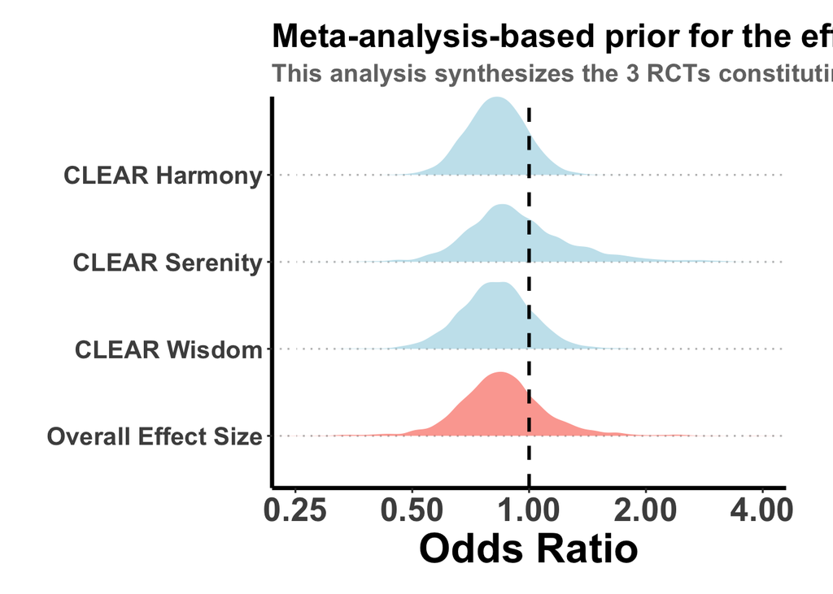

```r
#Sample the posterior distribution of study-level estimates and the overall estimate of treatment effect
study_es <- ma_model %>%
  spread_draws(r_study[study, ], b_bpd) %>%
  mutate(b_bpd = r_study + b_bpd, #Create treatment effect estimates for each study
         type = "Study-level estimate") #Clarify that this is the treatment effect for each study


pooled_es <- spread_draws(ma_model, b_bpd) %>%
  mutate(study = "Overall Effect Size", #Clarify that this is the pooled/overall treatment effect
         type = "Pooled estimate") #Same

#Exponentiate to get odds instead of log-odds ratio
fp_data <- bind_rows(study_es, pooled_es) %>%
  mutate(b_bpd = b_bpd %>% exp)

# Assuming 'author' is the column in your dataset that contains these names
# Replace 'Goldber' with 'Clear Wisdom'
fp_data$study <- gsub("goldberg", "CLEAR Wisdom", fp_data$study)

# Replace 'Laufs' with 'Clear Serenity'
fp_data$study <- gsub("laufs", "CLEAR Serenity", fp_data$study)

# Replace 'Ray' with 'Clear Harmony'
fp_data$study <- gsub("ray", "CLEAR Harmony", fp_data$study)


#Create title and subtitles for the plot
main_title <- "Meta-analysis-based prior for the effectiveness of BPD in preventing MACE"
subtitle <- "This analysis synthesizes the 3 RCTs constituting the RCT evidence base for BPD prior to the CLEAR Trial."

library(forcats)


# Assuming fp_data$study is a factor with levels ordered as you originally had them
# Reverse the levels to put 'Overall Effect Size' at the bottom
fp_data$study <- fct_rev(fp_data$study)

# Now plot your data with ggplot2
g=ggplot(data = fp_data, aes(y = study, x = b_bpd, fill = type)) +
  geom_density_ridges(col = NA, scale = 0.9, alpha = 0.7) +
  geom_vline(xintercept = 1, color = "black", lwd = 1, linetype = 2) +
  scale_fill_manual(values = c("salmon","lightblue")) + # Make sure the colors are in the right order
  ggtitle(main_title, subtitle = subtitle) +
  scale_y_discrete(name = "Study") +
  scale_x_continuous(name = "Odds Ratio", trans = "log", breaks = c(0.25, 0.5, 1, 2, 4)) +
  coord_cartesian(xlim = c(0.25, 4)) +
  theme_pubclean() +
  theme(text = element_text(size = 23),
        plot.title = element_text(face = "bold", hjust = 0.0, size = 20),
        plot.subtitle = element_text(face = "bold", size = 15, hjust = 0.0, color = "grey45"),
        axis.text.x = element_text(size = 20, face = "bold"),
        axis.text.y = element_text(size = 15, face = "bold"),
        axis.title.x = element_text(size = 25, face = "bold"),
        axis.title.y = element_blank(),
        axis.line = element_line(colour = "black", linewidth = 1.2),
        plot.margin = margin(0.5, 1, 0.5, 1, "cm"),
        legend.background = element_rect(fill = "transparent"),
        legend.position = "none",
        legend.text = element_text(size = 12, face = "bold"),
        legend.key.width = unit(1.5, "cm"),
        legend.key.height = unit(0.75, "cm"))

g
```

```r
ggsave(g,file="~/Library/CloudStorage/Dropbox-Personal//metaplot.png",width = 15,height=10)
```

## Now let’s use this as a prior

We will show with MCMC and with conjugate normal

```r
tryCatch({
  # Your R code that might cause errors
}, error = function(e) {
  # Write the error to a log file
  writeLines(as.character(e$message), "error_log.txt")
})

# Enter the data from the table into a data frame
meta_data <- data.frame(
  study = c("Goldberg et al., 2019", "Laufs et al., 2019", "Ray et al., 2019", "Nissen et al., 2023"),
  group = rep(c("Bempedoic Acid", "Placebo"), each = 4),
  events = c(32, 9, 68, 831, 21, 1, 42, 927), ## add a 1 to make it computable
  total = c(522, 234, 1487, 6992, 257, 111, 742, 6978)
)


# Likelihood data from the Nissen study
likelihood_data <- meta_data[meta_data$study == "Nissen et al., 2023",]

ma_bpd_lnor <- round(ma_bpd_par$Estimate, 2)
#Standard error of the log odds ratio
ma_bpd_lnor_sd <- round(ma_bpd_par$Est.Error, 2)

# Convert 'group' to a factor and create a binary treatment indicator
likelihood_data$bpd <- ifelse(likelihood_data$group == "Bempedoic Acid", 1, 0)

library(brms)
# Define the prior
# Define the mean and standard deviation for the log OR
log_or_mean <- ma_bpd_lnor  # Mean log OR
log_or_sd <- ma_bpd_lnor_sd    # Standard deviation of the log OR

# Assuming 'bpd' is the name of the variable for the treatment effect in your model
# Set the prior using the mean and standard deviation
nissen_prior <- set_prior(
  paste("normal(", log_or_mean, ",", log_or_sd, ")"),
  class = "b",
  coef = "bpd"
)

# Verify the prior
nissen_model <- brm(
  formula = bf(events | trials(total) ~ bpd),  # Update 'bpd' if your variable name is different
  data = likelihood_data,
  family = binomial(),
  prior = nissen_prior,
  seed = 102,
  control = list(adapt_delta = 0.95),verbose=FALSE
)

#saveRDS(nissen_model,"~/Library/CloudStorage/Dropbox-Personal/nissen_model.rds")
```

# Summary of the Nissen study model

```r
#nissen_model=readRDS("~/Library/CloudStorage/Dropbox-Personal/nissen_model.rds")
summary(nissen_model)
```

```
##  Family: binomial
##   Links: mu = logit
## Formula: events | trials(total) ~ bpd
##    Data: likelihood_data (Number of observations: 2)
##   Draws: 4 chains, each with iter = 2000; warmup = 1000; thin = 1;
##          total post-warmup draws = 4000
##
## Population-Level Effects:
##           Estimate Est.Error l-95% CI u-95% CI Rhat Bulk_ESS Tail_ESS
## Intercept    -1.87      0.03    -1.94    -1.81 1.00     2433     2035
## bpd          -0.13      0.05    -0.23    -0.03 1.00     3030     2605
##
## Draws were sampled using sampling(NUTS). For each parameter, Bulk_ESS
## and Tail_ESS are effective sample size measures, and Rhat is the potential
## scale reduction factor on split chains (at convergence, Rhat = 1).
```

Now let’s show that this matches with our conjugate analysis

```r
# Given data from the table
n_treatment <- 6992
events_treatment <- 831
n_control <- 6978
events_control <- 927

# Calculate the odds ratio (OR)
or <- (events_treatment / (n_treatment - events_treatment)) / (events_control / (n_control - events_control))

# Convert OR to logOR
log_or <- log(or)

# Calculate the standard error of the logOR
se_log_or <- sqrt((1 / events_treatment) + (1 / (n_treatment - events_treatment)) + (1 / events_control) + (1 / (n_control - events_control)))


calc_conjugate_posterior(log_or = log_or,se = se_log_or,prior = list(mu=ma_bpd_lnor,sigma=ma_bpd_lnor_sd))
```

```
## $mu
## [1] -0.1284681
##
## $sigma
## [1] 0.0501946
```

```r
pm=calc_conjugate_posterior(log_or = log_or,se = se_log_or,prior = list(mu=ma_bpd_lnor,sigma=ma_bpd_lnor_sd))

## we shos that these are quite close and differ likely because we also place a prior on baseline effects here
```

Now let’s analysie the posterior in light of the old evidence

First we simulate from each distribution:

```r
prior_sim <- rnorm(n = 10000, #Number of simulations
      mean = ma_bpd_lnor, #The log-OR from our meta-analysis
      sd = ma_bpd_lnor_sd) #The standard error of the log-OR from our meta-analysis


#likelihood sim
likelihood_sim <- rnorm(n = 10000,
                   mean = log_or,
                   sd = se_log_or)

## posterior sim
post_sim <- rnorm(n = 10000,
                   mean = -0.13,
                   sd = 0.05)



##Let us recap the 3 distributions we now have:
# "prior_sim", which contains our prior (obtained from the meta-analysis)
# "likelihood_sim" which contains the data from the CLEAR2 Ttrial
# "post_sim" which contains the data from our posterior (the combination of the above 2)
```

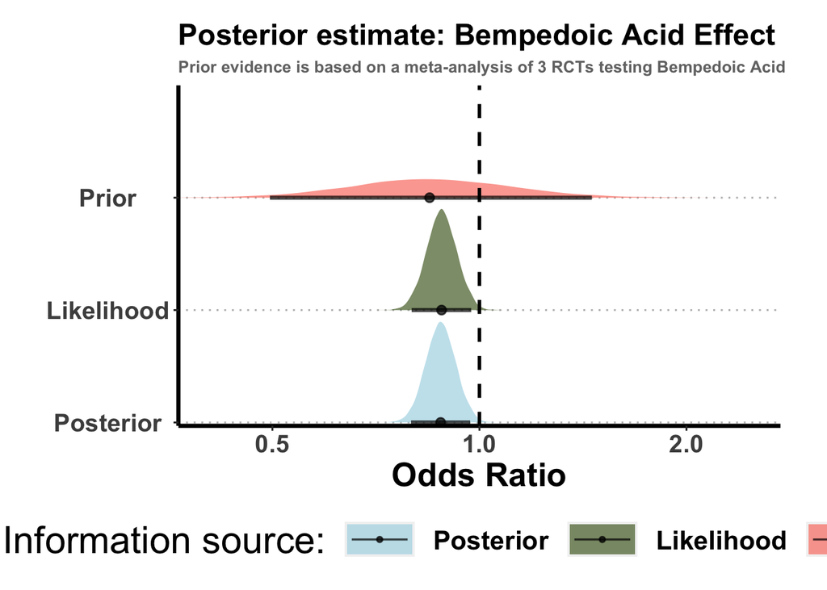

```r
#First, let us create a dataframe containing the above 3 simulations
sims <- data.frame(sim_lnor = c(prior_sim, likelihood_sim, post_sim), #This column contains the results of our simulations (each of length 10,000)
           sim_type = rep(c("Prior", "Likelihood", "Posterior"), each = 10000) #This column contains the labels of these simulations so we can identify which simulation each row belongs to
           )

#Arrange sim_type so that it shows up with the prior on top, the posterior at the bottom, and likelihood in the middle.
sims$sim_type <- factor(sims$sim_type, levels = c("Posterior", "Likelihood", "Prior"))

#Create title and subtitles for the plot
main_title <- "Posterior estimate: Bempedoic Acid Effect"
subtitle <- "Prior evidence is based on a meta-analysis of 3 RCTs testing Bempedoic Acid"


#Now, let us visualize this:
#Plot
g1=ggplot(data = sims,
       aes(y = sim_type,
           x = exp(sim_lnor),
           fill = sim_type
       )) +
  #Add Density plots
  stat_halfeye(alpha = 0.7, .width = 0.95) +
  #Set colors
  scale_fill_manual(name = "Information source:",
                    values = c("lightblue", "darkolivegreen", "salmon")) +
  #Create title
  ggtitle(main_title,
          subtitle = subtitle) +
  geom_vline(xintercept = 1, color = "black",
             lwd = 1, linetype = 2) +
  #Set x-axis limit
  coord_cartesian(xlim = c(0.4, 2.5)) +
  #X and Y axes aesthetics
  scale_y_discrete(name = NULL, expand = c(0, 0.03)) +
  scale_x_continuous(name = "Odds Ratio",
                     trans = "log",
                     breaks = c(0.5, 1, 2)) +
  #Set theme
  theme_pubclean() +
  theme(text = element_text(size = 23),
        plot.title=element_text(face = "bold", hjust = 0.0, size = 18),
        plot.subtitle = element_text(face = "bold", size = 10, hjust = 0.0, color = "grey45"),
        axis.text.x = element_text(size = 15, face = "bold"),
        axis.text.y = element_text(size = 15, face = "bold", hjust = 0.5),
        axis.title.x = element_text(size = 20, face = "bold"),
        axis.title.y = element_blank(),
        axis.line = element_line(colour = "black", linewidth = 1.2),
        plot.margin = margin(0.5, 1, 0.5, 1, "cm"),
        legend.background = element_rect(fill = "transparent"),
        legend.position = "bottom",
        legend.text = element_text(size = 16, face = "bold"),
        legend.key.width = unit(1.5, "cm"),
        legend.key.height = unit(0.75, "cm")
        )

g1
```

```r
ggsave(g1,file="~/Library/CloudStorage/Dropbox-Personal/post.png",width = 11,height=10)
```

Now, let’s report the 95% CI and the posteriors under this meta -analysis results

```r
pnorm(0,mean= -0.13 ,sd = 0.05)
```

```
## [1] 0.9953388
```

```r
pnorm(log_mcid,mean= -0.13 ,sd = 0.05)
```

```
## [1] 0.5958949
```

```r
summary(nissen_model)
```

```
##  Family: binomial
##   Links: mu = logit
## Formula: events | trials(total) ~ bpd
##    Data: likelihood_data (Number of observations: 2)
##   Draws: 4 chains, each with iter = 2000; warmup = 1000; thin = 1;
##          total post-warmup draws = 4000
##
## Population-Level Effects:
##           Estimate Est.Error l-95% CI u-95% CI Rhat Bulk_ESS Tail_ESS
## Intercept    -1.87      0.03    -1.94    -1.81 1.00     2433     2035
## bpd          -0.13      0.05    -0.23    -0.03 1.00     3030     2605
##
## Draws were sampled using sampling(NUTS). For each parameter, Bulk_ESS
## and Tail_ESS are effective sample size measures, and Rhat is the potential
## scale reduction factor on split chains (at convergence, Rhat = 1).
```